# Flashing Large Mammals - exploring the data

2021-01-06

```r
library(tidyverse)
library(lubridate)
```

```r
library(overlap)
# All the tibbles from Data_explor_setup.R, and package + function from Density.R
{
  obs <- read_csv("obs_datexpl.csv", col_types = cols(
    loc = col_factor(),
    date = col_date(format = ""),
    image_id = col_double(),
    timeserie_id = col_double(),
    dataset = col_double(),
    captured_at_exif = col_datetime(format = ""),
    predicted_species = col_character(),
    validated_species = col_character(),
    distance = col_double(),
    num_animals = col_double(),
    datetime = col_datetime(format = ""),
    `Kam.nr. til blitskamera` = col_double(),
    flash = col_logical(),
    period = col_factor(levels = c("0_1", "1_1", "0_2", "1_2", "0_3", "Control")),
    hour = col_double(),
    mins = col_double(),
    secs = col_double(),
    rad = col_double()
  ))
  effort <- read_csv("effort_datexpl.csv", col_types = cols(
    loc = col_factor(),
    date = col_date(format = ""),
    period = col_factor(levels = c("0_1", "1_1", "0_2", "1_2", "0_3", "Control")),
    abc = col_factor(levels = c("A", "B", "C")),
    cam_mod = col_factor()
  ))
  stations <- read_csv("stations.csv", col_types = cols(
    loc = col_factor(),
    x = col_double(),
    y = col_double(),
    abc = col_factor(levels = c("A", "B", "C")),
    cam_mod = col_factor()
  ))
}
# functions building on overlap package
overlap_flash <- function(x, colour = c("black", "blue"), rug = FALSE) {
  x0 <- obs[obs$validated_species %in% x & obs$flash == FALSE, ]$rad
  x1 <- obs[obs$validated_species %in% x & obs$flash == TRUE, ]$rad
  overlapPlot(x1, x0, main = str_to_title(x), linecol = rep(colour, 2), rug = rug, linewidth = c(2, 2), olapcol = "darkgrey", extend = "lightgrey")
  x.est <- round(overlapEst(x1, x0, type = "Dhat4"), 3)
  n0 <- length(x0)
  n1 <- length(x1)
  legend("top", legend = str_c("Dhat4", x.est, sep = " = "), bty = "n")
  legend("bottomleft", legend = c(str_c("LED n", n1, sep = " = "), str_c("    IR n", n0, sep = " = ")),
         col = colour, lty = c(1, 2), lwd = 2, bty = "7")
}
overlap_flash_2sp <- function(x, y, col_x, col_y, rug = FALSE) {
  x1 <- obs[obs$validated_species %in% x & obs$flash == TRUE, ]$rad  # sp X when flash = TRUE
  x0 <- obs[obs$validated_species %in% x & obs$flash == FALSE, ]$rad # - - | | - -    = FALSE
  y1 <- obs[obs$validated_species %in% y & obs$flash == TRUE, ]$rad # sp Y when flash = TRUE
  y0 <- obs[obs$validated_species %in% y & obs$flash == FALSE, ]$rad # - - | | - -    = FALSE
  par(mfrow = c(2, 2)) # setting plot parameters: 2x2 windows
  overlap_flash(x, col_x, rug) # using the overlap_flash function for single species w/w/o flash-plot
  overlap_flash(y, col_y, rug) #                 - - | | - -
  overlapPlot(x0, y0,  # overlapping 2 species plot - flash = FALSE
    main = str_to_title("whithout flash"), rug = rug, linecol = c(col_x, col_y),
    linetype = c(1, 1), linewidth = c(2, 2), olapcol = "darkgrey", extend = "lightgrey"
  )
  overlapPlot(x1, y1,  # overlapping 2 species plot - flash = TRUE
    main = str_to_title("with flash"),     rug = rug, linecol = c(col_x, col_y),
    linetype = c(2, 2), linewidth = c(2, 2), olapcol = "darkgrey", extend = "lightgrey"
  )
  xy0.est <- round(overlapEst(x0, y0, type = "Dhat4"), 3)  # estimated overlap using Dhat4 - flash = FALSE
  xy1.est <- round(overlapEst(x1, y1, type = "Dhat4"), 3)  #           - - | | - -         - flash = TRUE
  legend("top", legend = str_c("Dhat4", xy0.est, sep = " = "), bty = "n") # Dhat4 label
  legend("bottomleft", legend = c(x, y), col = c(col_x, col_y), lty = c(1, 1), lwd = 2, bty = "n") # legend
  legend("top", legend = str_c("Dhat4", xy1.est, sep = " = "), bty = "n")
  legend("bottomleft", legend = c(x, y), col = c(col_x, col_y), lty = c(2, 2), lwd = 2, bty = "n")
}
```

# Presenting the data

```r
min(obs$date) # [1] "2019-01-15"
```

```
## [1] "2019-01-15"
```

```r
max(obs$date) # [1] "2020-02-17"  #but last field date was 2020-02-26 at camera 850 & 822!!
```

```
## [1] "2020-02-17"
```

```r
sp_focus <- c("ekorn", "elg", "grevling", "hare", "raadyr", "rev")
obstation <- obs %>% left_join(stations, by = "loc") %>% filter(validated_species %in% sp_focus) %>% unite(abc, abc, flash) # unite lager ny faktor med alle kombinasjoner

#obstation %>% with(table(validated_species, abc)) %>%
 # knitr::kable(caption = "Table with kable")

# Total nr of image (rapidfire)series can be presented by:
length(unique(obs$timeserie_id)) # identical numbers for timeserie_id and image_id
```

```
## [1] 24841
```

```r
length(unique(obs$image_id))     # is it because only one picture is selected per timeseries?
```

```
## [1] 24841
```

```r
obs_by_loc <- obs %>% group_by(loc) %>% summarise(n = length(timeserie_id)) %>% arrange(desc(n))
```

```r
# plot(obs_by_loc)
```

### Blank images

```r
# Filtering out timelapse-pictures in Reconyx (455 is the only Browning-camera that has significant number of pictures here)
timelapse <- obs %>% left_join(stations, by = "loc") %>%
  filter(hour %in% c(8, 13) & mins == 0  &  secs == 0  &  validated_species == "nothing") # == "nothing" to single out tinelapse-photos
summary(timelapse)
```

```
##       loc            date               image_id        timeserie_id
##  513    : 406   Min.   :2019-01-16   Min.   : 968433   Min.   :142126
##  864    : 398   1st Qu.:2019-04-24   1st Qu.:1939653   1st Qu.:302987
##  15     : 396   Median :2019-07-24   Median :3414484   Median :519712
##  257    : 396   Mean   :2019-07-25   Mean   :3413771   Mean   :497684
##  651    : 395   3rd Qu.:2019-10-24   3rd Qu.:5156856   3rd Qu.:700153
##  656    : 395   Max.   :2020-02-17   Max.   :5557428   Max.   :808095
##  (Other):5887
##     dataset     captured_at_exif predicted_species  validated_species
##  Min.   :1360   Min.   :NA       Length:8273        Length:8273
##  1st Qu.:2538   1st Qu.:NA       Class :character   Class :character
##  Median :4161   Median :NA       Mode  :character   Mode  :character
##  Mean   :4088   Mean   :NA
##  3rd Qu.:5636   3rd Qu.:NA
##  Max.   :6787   Max.   :NA
##                 NA's   :8273
##     distance     num_animals      datetime
##  Min.   : NA    Min.   : NA    Min.   :2019-01-16 08:00:00
##  1st Qu.: NA    1st Qu.: NA    1st Qu.:2019-04-24 08:00:00
##  Median : NA    Median : NA    Median :2019-07-24 08:00:00
##  Mean   :NaN    Mean   :NaN    Mean   :2019-07-26 07:45:12
##  3rd Qu.: NA    3rd Qu.: NA    3rd Qu.:2019-10-24 08:00:00
##  Max.   : NA    Max.   : NA    Max.   :2020-02-17 13:00:00
##  NA's   :8273   NA's   :8273
##  Kam.nr. til blitskamera   flash             period          hour
##  Min.   :3179            Mode :logical   0_1    : 743   Min.   : 8.000
##  1st Qu.:3199            FALSE:5419      1_1    :1598   1st Qu.: 8.000
##  Median :3203            TRUE :2854      0_2    :1177   Median : 8.000
##  Mean   :3201                            1_2    :1242   Mean   : 8.888
##  3rd Qu.:3207                            0_3    : 831   3rd Qu.: 8.000
##  Max.   :3211                            Control:2682   Max.   :13.000
##  NA's   :2489
##       mins        secs        rad              x                y
##  Min.   :0   Min.   :0   Min.   :2.094   Min.   :543279   Min.   :6581339
##  1st Qu.:0   1st Qu.:0   1st Qu.:2.094   1st Qu.:573273   1st Qu.:6620476
##  Median :0   Median :0   Median :2.094   Median :597516   Median :6629090
##  Mean   :0   Mean   :0   Mean   :2.327   Mean   :588875   Mean   :6629203
##  3rd Qu.:0   3rd Qu.:0   3rd Qu.:2.094   3rd Qu.:606816   3rd Qu.:6642088
##  Max.   :0   Max.   :0   Max.   :3.403   Max.   :619655   Max.   :6689057
##
##  abc          cam_mod
##  A:2489   Browning: 278
##  B:3212   Reconyx :7995
##  C:2572
##
##
##
##
```

```r
table(timelapse$hour[timelapse$cam_mod =="Reconyx"])
```

```
##
##    8   13
## 6526 1469
```

```r
table(timelapse$cam_mod)
```

```
##
## Browning  Reconyx
##      278     7995
```

```r
# table(timelapse$loc[timelapse$cam_mod == "Browning"])  #455 maybe has two cameras?
# table(timelapse$validated_species)  # when val_sp == "nothing" not specified: 10 other species present
# table(timelapse$validated_species[timelapse$hour == 13]) # elg:1, maar:2, menneske:3, raadyr:1
# table(timelapse$validated_species[timelapse$hour == 8]) # ekorn:1, fugl:9, gaupe:1, katt:1, menneske:1, raadyr:4, rev:2, ukjent:4

# Differentiate "nothing"-sequences and "nothing"-one-shots
# validated_species == "nothing" #by loc,
# and making an "independent event" criteria to distinguish repeated vegetation-triggering and other single-triggered events.
# TODO
library(data.table)
setDT(obs)[, event_id := 1L + cumsum(c(0L, diff(datetime) > 720)), by=.(loc, validated_species)]

# TODO obs %>% group_by(validated_species, event_id) %>% filter(validated_species == "nothing") %>% table(obs$loc)


names(obs)
```

```
##  [1] "loc"                     "date"
##  [3] "image_id"                "timeserie_id"
##  [5] "dataset"                 "captured_at_exif"
##  [7] "predicted_species"       "validated_species"
##  [9] "distance"                "num_animals"
## [11] "datetime"                "Kam.nr. til blitskamera"
## [13] "flash"                   "period"
## [15] "hour"                    "mins"
## [17] "secs"                    "rad"
## [19] "event_id"
```

## time series of all cameras

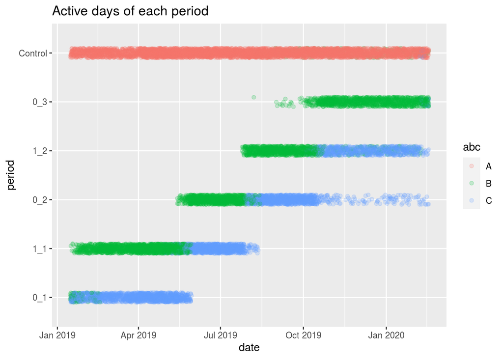

```r
p_timeseries <- ggplot(data = effort) +
  geom_jitter(mapping = aes(date, period, col = abc), alpha = 1 / 5, width = 0, height = 0.1)
p_timeseries +   labs(title = "Active days of each period")  # TODO # find a way to mark n cameras by groups (A = 19, B = 20, C = 20)
```

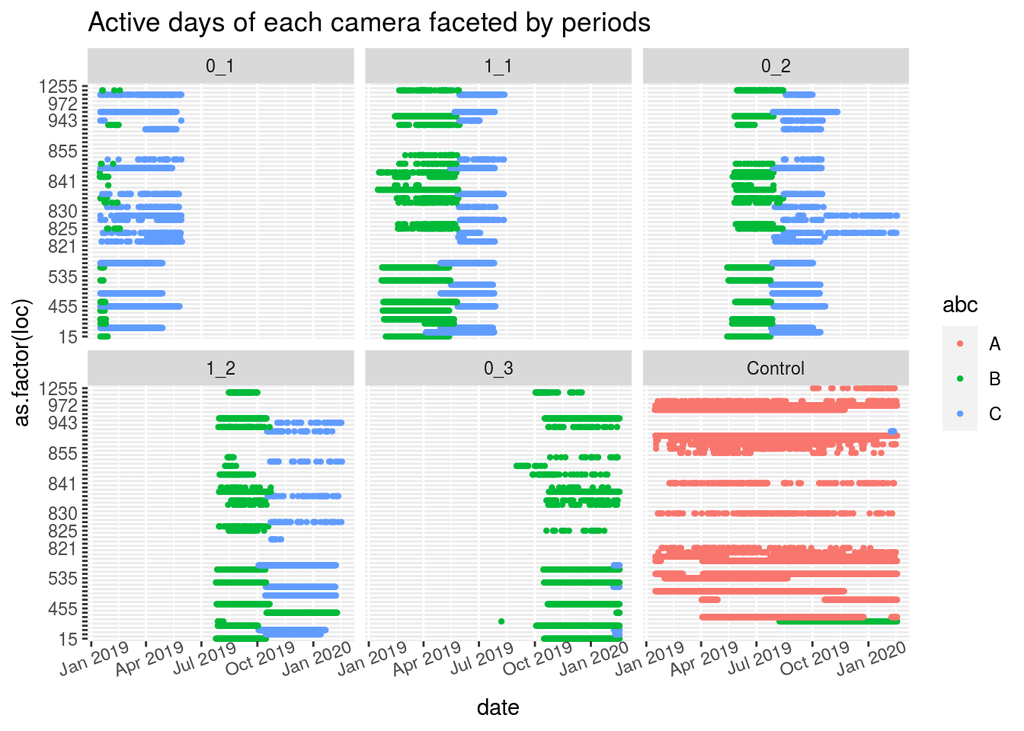

```r
p_timeseries_facet <- ggplot(effort, aes(date, as.factor(loc))) +
  theme(axis.text.x = element_text(angle = 20)) +
  facet_wrap(~period, nrow = 2) +
  scale_y_discrete(guide = guide_axis(check.overlap = T))
p_timeseries_facet + geom_point(aes(col = abc), size = .8) + labs(title = "Active days of each camera faceted by periods")
```

The cameras were divided into 3 groups a 20 cameras. Group A were the control group, and stayed unchanged. Group B and C were each equipped with an additional PC850 Reconyx camera, which has a white LED flash, with alternating periods of 3 months. Group B was first in each period, as seen in the first plot.

The second plots shows the effort from each camera, faceted by the periods. Unfortunately there is some debugging to do as *a camera from group B and one from C has fallen into the control period.* In addition, two cameras from group C enters/ stays in the second period without flash (0_2), instead of entering the 1_2-period. The same is true for a B camera, that enters 1_2 with the C group, a period late!

## Which species did we get?

```r
sp_all <- c("hare", "elg", "rev", "grevling", "maar", "gaupe", "ekorn", "raadyr", "hjort") # interesting species with enough datapoints
by_sp <- obs %>%
  left_join(stations, by = "loc") %>%
  group_by(validated_species)
passes <- summarise(by_sp,
  count = n(),   # flashed = mean(flash, na.rm = T), # don't know if i can find a relevant use of this
  abc = abc, period = period, flash = flash)
```

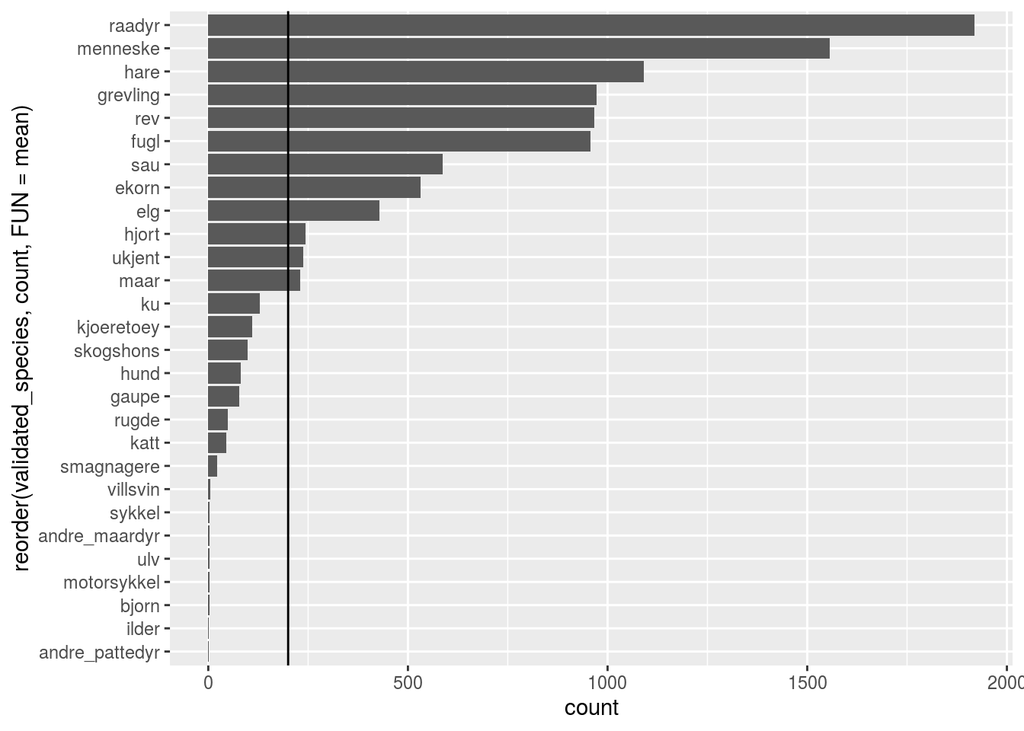

```r
passes %>%
  filter(!is.na(validated_species), !(validated_species %in% "nothing")) %>%
  ggplot() +
  geom_bar(aes(reorder(validated_species, count, FUN = mean)), position = "dodge") +  # shows actual counts of each species
  geom_hline(yintercept = 200) + coord_flip() # flip the axes
```

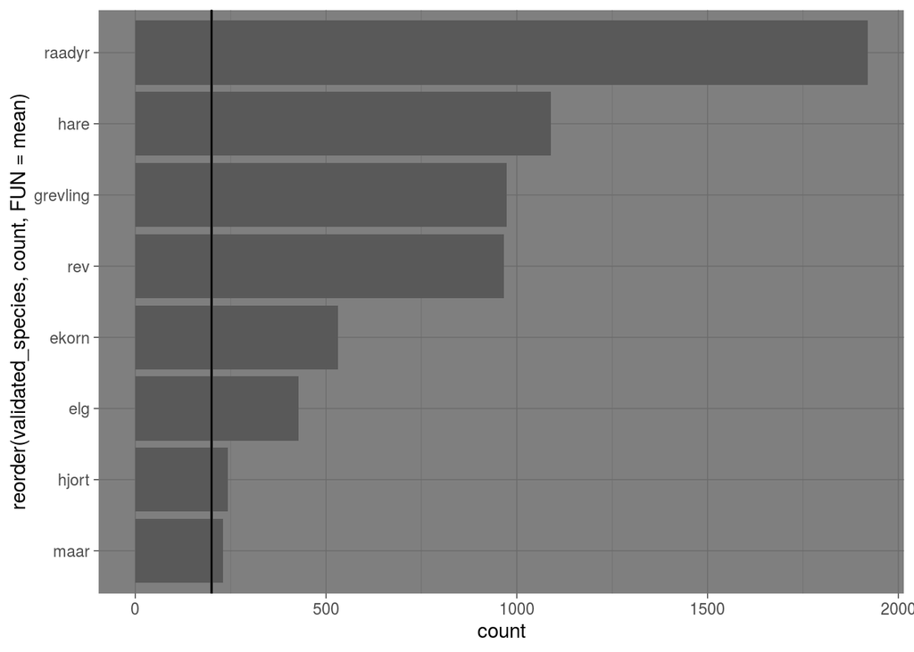

```r
# most datapoints on ekorn, elg, grevling, hare, raadyr, rev,
fjern <- c("nothing","hund", "menneske", "kjoeretoey", "motorsykkel", "ukjent", "sau", "ku", "fugl") # uninteresting or too general groups
p_sp_focus <- passes %>%
  filter(count > 200, !(validated_species %in% fjern), !is.na(validated_species)) %>%  # removing low counts and sp in 'fjern'
  ggplot() + scale_fill_brewer() + theme_dark() + geom_hline(yintercept = 200) + coord_flip()
p_sp_focus + geom_bar(aes(reorder(validated_species, count, FUN = mean)), position = "dodge") + geom_hline(yintercept = 200) # same as first plot, more filtered
```

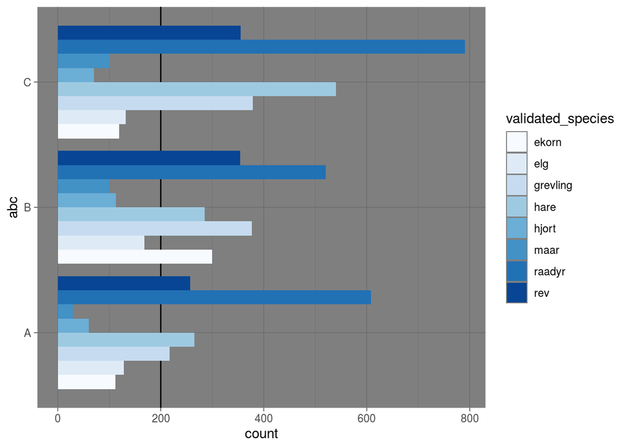

```r
p_sp_focus + geom_bar(aes(abc, fill = validated_species), position = "dodge")  # same as first plot, more filtered
```

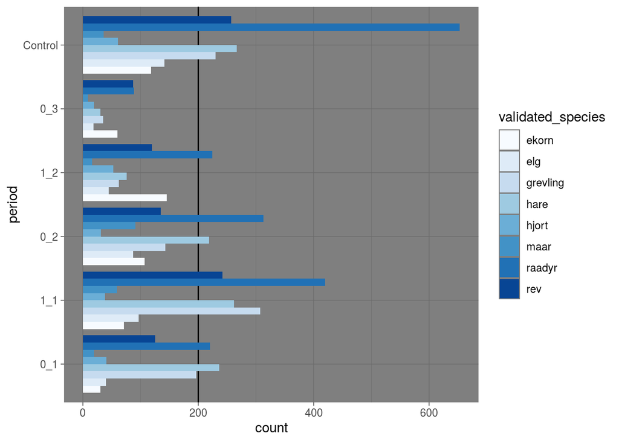

```r
p_sp_focus + geom_bar(aes(period, fill = validated_species), position = "dodge")
```

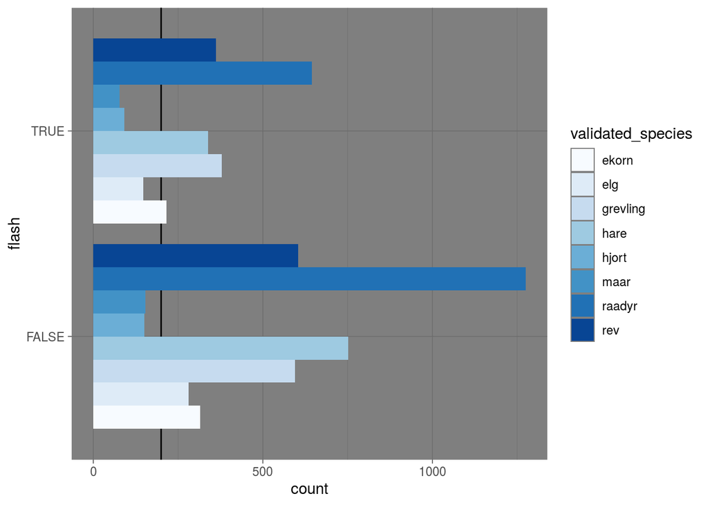

```r
p_sp_focus + geom_bar(aes(flash, fill = validated_species), position = "dodge")
```

Removing sightings of “nothing”, things related to humans, as well as NAs and birds (too general group), I am left with quite a few species still. Filtering for counts lower than 200 renders me the selection shown in the dark themed plots.

## Density plots showing activity patterns with and without flash

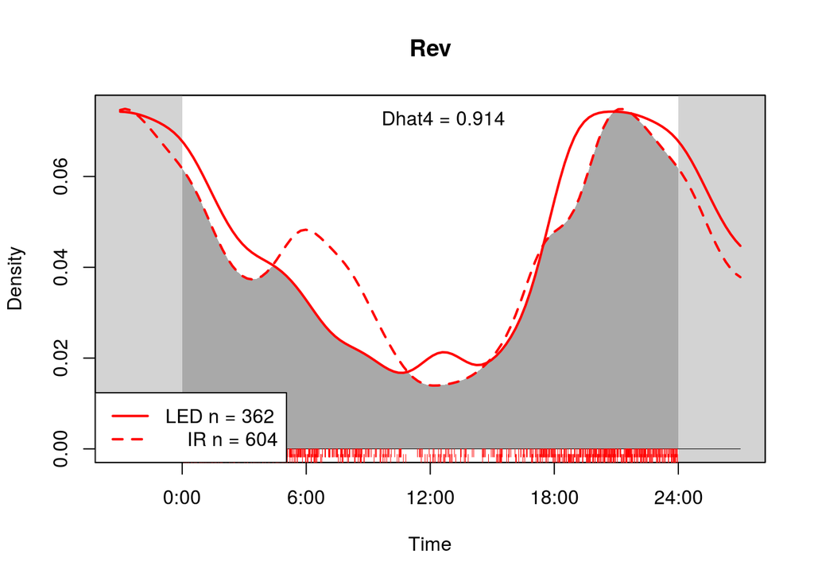

```r
overlap_flash("rev", "red", rug = TRUE)
```

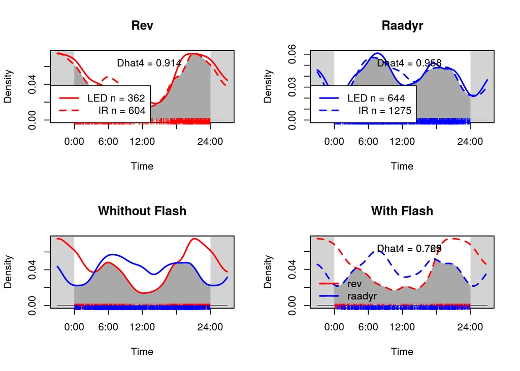

```r
overlap_flash_2sp("rev", "raadyr", "red", "blue", rug=TRUE)
```

Sites without white flash produces a more bumpy curve than does the sites with a flash. Proportion of foxes at sites are markedly lower before sunrise, and then higher afterwards. Could this simply be because of a lower detection rate when lacking the additional white flash? There is a resembling phenomenon happening in the evening twilight as well, right before the peak activity time of the fox, which happens before midnight.

The Dhat4 calculation reveals a larger difference in activity for foxes, than for roe deer, but seems to mainly stem from the twilight hours. Thus, it could be because of the size of the animals, rather than a reaction to the flash.

### Controlling for day-length

```r
# Dates <- as.POSIXct(obs$date, tz="CET")
# coords <- matrix(c(60.1, 10.6), nrow=1) # Rett nord for Oslo i longlat
# Coords <- sp::SpatialPoints(coords, proj4string=sp::CRS("+proj=longlat +datum=WGS84"))
# st <- sunTime(obs$rad, Dates, Coords)
#
# par(mfrow=2:1)
# densityPlot(st, col='red', lwd=2, xaxt='n', main="Sun time")
# axis(1, at=c(0, 6, 12, 18, 24),
#   labels=c("midnight", "sunrise", "noon", "sunset", "midnight"))
# densityPlot(simCalls$time, lwd = 2, main = "Clock time")
# par(mfrow=c(1,1))

# TODO # Sjå density.r for oppdatert skript
```

## Box plots

### of periods

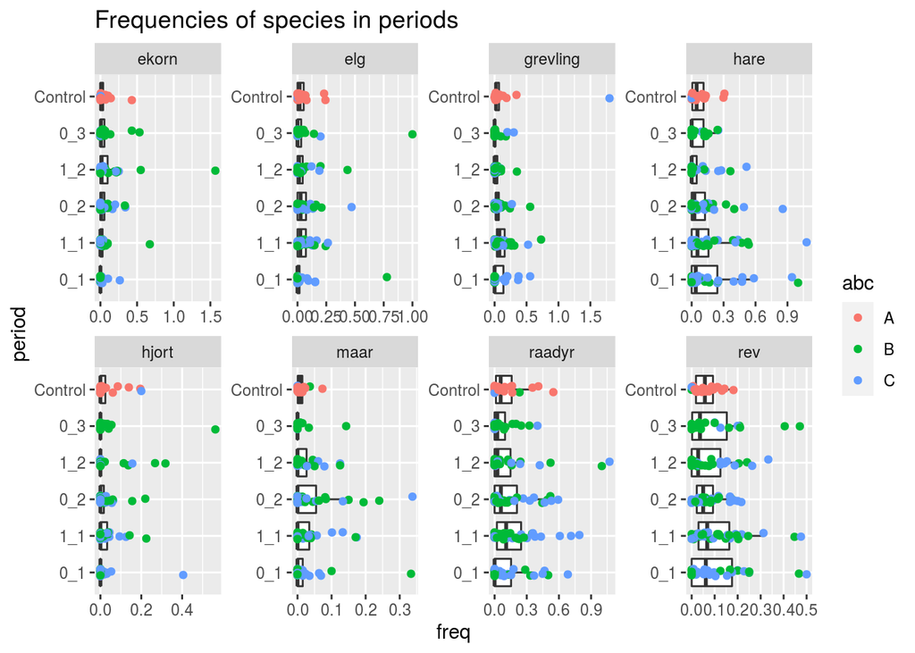

```r
freq <- read_csv("freq_datexpl.csv", col_types = cols(
  loc = col_factor(),
  period = col_factor(levels = c("0_1", "1_1", "0_2", "1_2", "0_3", "Control")),
  validated_species = col_character(),
  n.obs = col_double(),
  n.days = col_double(),
  freq = col_double(),
  flash = col_logical()
))
# frequency on periods, single or plural species
sp <- c("ekorn", "elg", "grevling", "hare", "hjort", "maar", "raadyr", "rev") # Species with the most datapoints
p_freq_per <- freq %>% # plot of frequency grouped by period
  filter(validated_species %in% sp) %>%
  left_join(stations, by = "loc") %>%
  ggplot(aes(period, freq)) +
  facet_wrap(~validated_species, scales = "free", nrow = 2) +
  labs(title = "Frequencies of species in periods")

# coloured with abc-grouping
p_freq_per + geom_boxplot(outlier.shape = NA) + # Remove outliers when overlaying boxplot with original data points
  geom_jitter(aes(col = abc), width = 0.1) + coord_flip() # add points for each camera
```

### of flash on/of

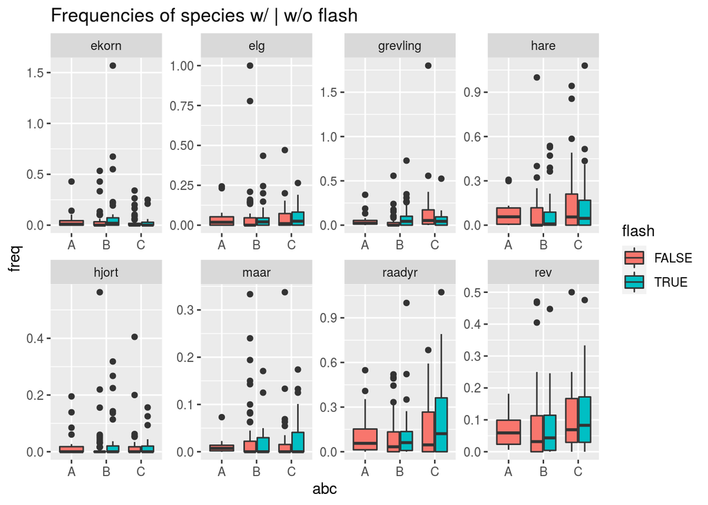

```r
freq %>% # plot of frequency grouped by abc and flash T/F
  filter(validated_species %in% sp) %>%
  left_join(stations, by = "loc") %>%
  ggplot(aes(abc, freq)) +
  facet_wrap(~validated_species, scales = "free", nrow = 2) + # scales = "free"
  labs(title = "Frequencies of species w/ | w/o flash") +
  geom_boxplot(aes(fill = flash))
```

I can’t really see any obvious effect of the flash in any of these plots.

[session information not shown]

```r
# packrat
# checkpoint
```

If you want your code to be reproducible in the long-run (i.e. so you can come back to run it next month or next year), you’ll need to track the versions of the packages that your code uses. A rigorous approach is to use *packrat*, [link](http://rstudio.github.io/packrat/), which stores packages in your project directory, or *checkpoint*, [link](https://github.com/RevolutionAnalytics/checkpoint), which will reinstall packages available on a specified date. A quick and dirty hack is to include a chunk that runs sessionInfo() — that won’t let you easily recreate your packages as they are today, but at least you’ll know what they were.